# Untargeted Metabolomics Data Matrix

Pietro Franceschi | pietro.franceschi@fmach.it

## Starting Ideas

1. The data matrix will be **FAT**
2. The variable we measure are **not** metabolites
3. We want to process the raw data coming from the instrument and organize them in a data matrix

## LC/GC MS

**THREE dimensional data**

1. Neutral molecules are separated “in time” on the bases of their chemical properties
2. The separated molecules are ionized and then weighted in the mass spectrometer
3. During ionization each molecule produces more than on ion

**We have more ions than metabolites**

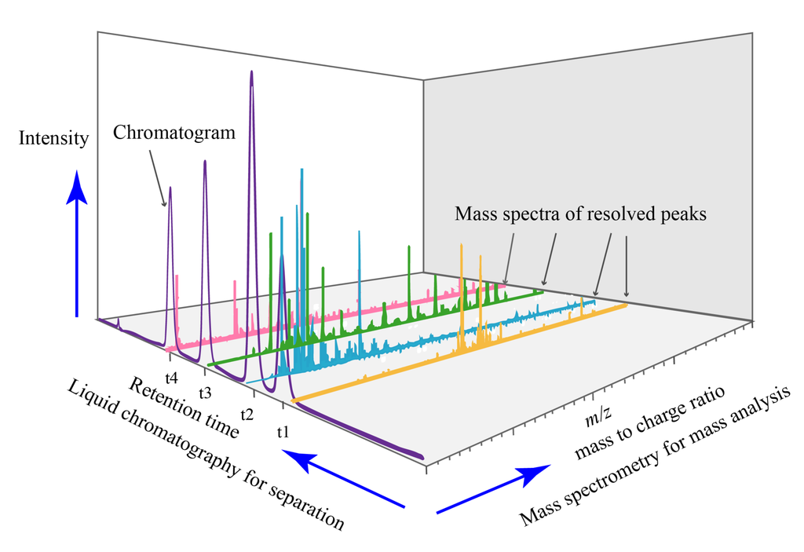

## LC/GC - MS: what we measure

- Dimension 1: separation time (in sec or minutes)
- Dimension 2: “weight of the molecule” (measured as mass/charge, *m/z*)
- The intensity of the different ions coming from the same molecule are highly correlated
- Due to analytical variability retention time and m/z slightly drift over time
- Relative quantification

## Ion Mobility

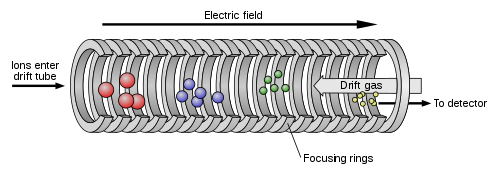

- The ions coming from the ionization interface are further separated on the base of their “structure”
- Ion mobility does not help in controlling the matrix effect

## Direct Infusion (DIMS)

- The chromatographic separation is removed
- The sample is directly ionized in the interface
- High speed
- Huge matrix effect

## NMR

**One dimensional data**

NMR measures a physical property (their frequency of resonance) of atomic nuclei in presence of a magnetic field. The **measured frequency of resonance depends on the chemical environment**, i.e. on the structure of the molecule which contains an active NMR nucleus

1. No separation in time is (generally) needed
2. Each molecule/metabolite produces more than one NMR peak
3. NMR is more reproducible, but less sensitive compared to MS based analytical techniques

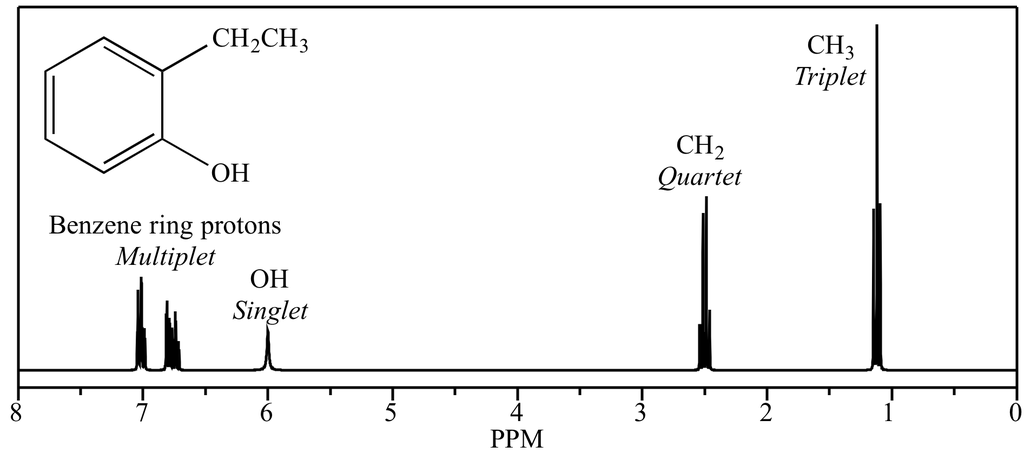

- More peaks per molecule
- functional groups from different molecules can add-up
- intensity is proportional to the number of molecules so NMR is inherently quantitative

## NMR: what we measure

- Dimension 1: shift in frequency to a reference in **ppm**
- The intensity of the different peaks coming from the same molecule are highly correlated
- In metabolomics, the ppm scale is *binned* (*bucketing*) to account for slight misalignments